# Bicicletas_rentadas_x_día

Author

CFLM

# KNN. Regresión.

El proceso de alquiler de bicicletas compartidas está muy correlacionado con las condiciones ambientales y estacionales. Por ejemplo, las condiciones meteorológicas, la precipitación, el día de la semana, la estación, la hora del día, etc. pueden afectar a los comportamientos de alquiler. El conjunto de datos principales está relacionado con el registro histórico de dos años correspondiente a los años 2011 y 2012 del sistema Capital Bikeshare, Washington D.C., EE. UU., que está disponible públicamente en http://capitalbikeshare.com/system-data. Los datos fueron agregados cada dos horas y cada día y, a continuación se añadió la información meteorológica y estacional correspondiente. La información meteorológica se extrajo de http://www.freemeteo.com.

Realizar una Regresión para la predicción del número de bicicletas de alquiler por día (cnt) en función del entorno y de la estación, por ende se usará el archivo con datos diarios. Utilice las variables predictoras: - `atemp` (sensación térmica normalizada en grados centígrados), - `hum` (humedad normalizada), - `windspeed` (velocidad del viento normalizada). La variable a ser predicha es `cnt`.

## Librerías

```r
pacman::p_load(tidyverse,
               tidymodels,
               ggplot2,
               dplyr,
               janitor,
               ISLR,
               inspectdf,
               GGally,
               optimx,
               kknn)
```

## Datos

```r
datos_1<- read.csv("day.csv")
```

```r
summary(select(datos_1, atemp, hum, windspeed, cnt))
```

```
     atemp              hum           windspeed            cnt
 Min.   :0.07907   Min.   :0.0000   Min.   :0.02239   Min.   :  22
 1st Qu.:0.33784   1st Qu.:0.5200   1st Qu.:0.13495   1st Qu.:3152
 Median :0.48673   Median :0.6267   Median :0.18097   Median :4548
 Mean   :0.47435   Mean   :0.6279   Mean   :0.19049   Mean   :4504
 3rd Qu.:0.60860   3rd Qu.:0.7302   3rd Qu.:0.23321   3rd Qu.:5956
 Max.   :0.84090   Max.   :0.9725   Max.   :0.50746   Max.   :8714
```

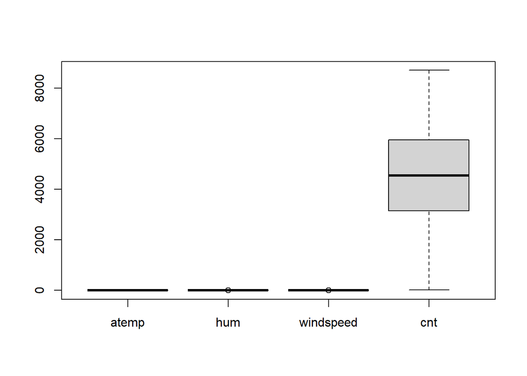

```r
boxplot(list(atemp = datos_1$atemp, hum = datos_1$hum, windspeed = datos_1$windspeed, cnt = datos_1$cnt))
```

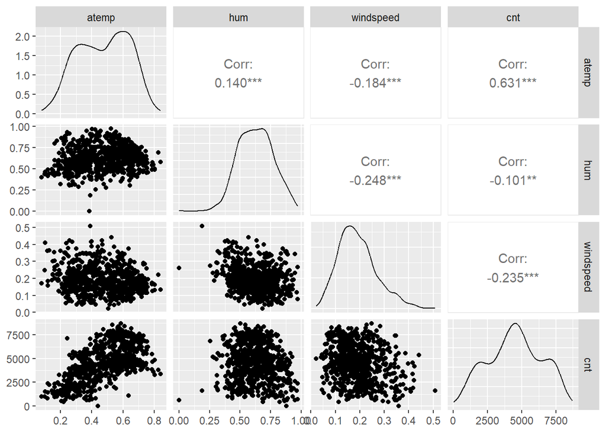

```r
ggpairs(select(datos_1, atemp, hum, windspeed, cnt))
```

```r
set.seed(10)

particion <- initial_split(datos_1, prop = 0.8, strata = cnt)

cv_entre <- training(particion)
cv_test <- testing(particion)
```

```r
knn_spec<- nearest_neighbor() |>
  set_engine("kknn")|>
  set_args(neighbors = tune())|>
  set_mode("regression")
```

```r
rec_spec <- recipe(cnt ~ atemp + hum + windspeed, data = cv_entre)|>
  step_normalize(all_numeric_predictors())
```

```r
cv_ft <- workflow() |>
  add_recipe(rec_spec) |>
  add_model(knn_spec)
```

```r
set.seed(10)
obj_rem<- vfold_cv(cv_entre, v=10)
```

```r
#seq(1,10)) por q son 10 folds
vecinos <- tibble(neighbors = seq(1,10))

class(vecinos)
```

```
[1] "tbl_df"     "tbl"        "data.frame"
```

```r
tune_res<- tune_grid(
  object = cv_ft,
  resamples = obj_rem,
  grid = vecinos)
```

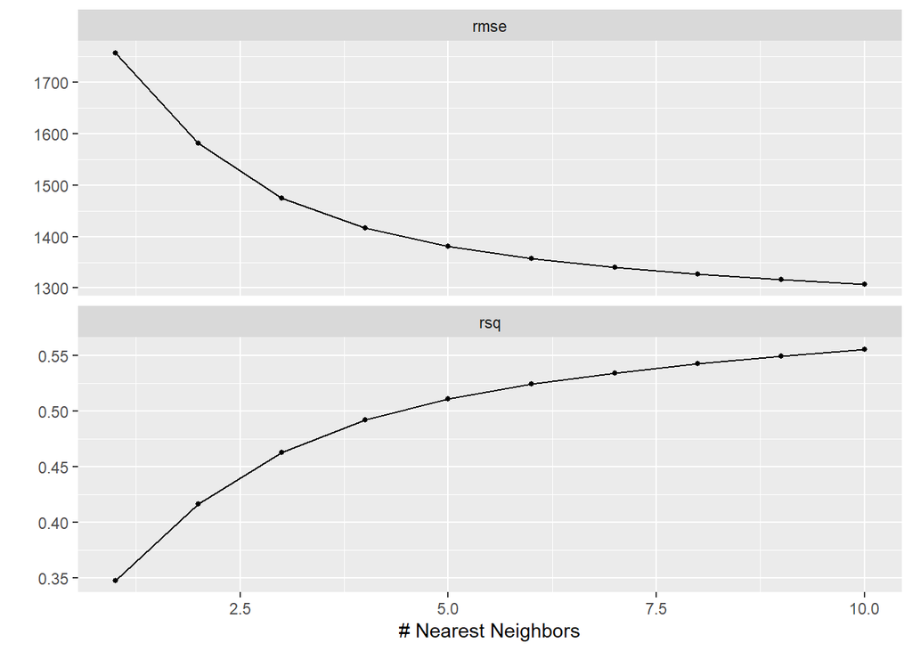

```r
autoplot(tune_res)
```

```r
show_best(tune_res, metric = "rmse")
```

```
# A tibble: 5 × 7
  neighbors .metric .estimator  mean     n std_err .config
      <int> <chr>   <chr>      <dbl> <int>   <dbl> <chr>
1        10 rmse    standard   1307.    10    38.4 Preprocessor1_Model10
2         9 rmse    standard   1316.    10    37.7 Preprocessor1_Model09
3         8 rmse    standard   1327.    10    37.2 Preprocessor1_Model08
4         7 rmse    standard   1340.    10    37.1 Preprocessor1_Model07
5         6 rmse    standard   1357.    10    36.8 Preprocessor1_Model06
```

```r
mejor_hiperparametro<- select_by_one_std_err(tune_res,
                                             neighbors,
                                             metric = "rmse")
```

```r
final_ft<- finalize_workflow(cv_ft,
                             mejor_hiperparametro)
final_ft
```

```
══ Workflow ════════════════════════════════════════════════════════════════════
Preprocessor: Recipe
Model: nearest_neighbor()

── Preprocessor ────────────────────────────────────────────────────────────────
1 Recipe Step

• step_normalize()

── Model ───────────────────────────────────────────────────────────────────────
K-Nearest Neighbor Model Specification (regression)

Main Arguments:
  neighbors = 7

Computational engine: kknn
```

```r
final_fit<- fit(final_ft,
                cv_entre)
final_fit
```

```
══ Workflow [trained] ══════════════════════════════════════════════════════════
Preprocessor: Recipe
Model: nearest_neighbor()

── Preprocessor ────────────────────────────────────────────────────────────────
1 Recipe Step

• step_normalize()

── Model ───────────────────────────────────────────────────────────────────────

Call:
kknn::train.kknn(formula = ..y ~ ., data = data, ks = min_rows(7L,     data, 5))

Type of response variable: continuous
minimal mean absolute error: 1110.581
Minimal mean squared error: 1842436
Best kernel: optimal
Best k: 7
```

```r
fit_test<- augment(final_fit,
                   new_data = cv_test)
```

```r
fit_test |>
  metrics(cnt, .pred)
```

```
# A tibble: 3 × 3
  .metric .estimator .estimate
  <chr>   <chr>          <dbl>
1 rmse    standard    1370.
2 rsq     standard       0.460
3 mae     standard    1078.
```

```r
config_metricas<- metric_set(rmse, mae)
config_metricas(fit_test,
                truth = cnt,
                estimate = .pred)
```

```
# A tibble: 2 × 3
  .metric .estimator .estimate
  <chr>   <chr>          <dbl>
1 rmse    standard       1370.
2 mae     standard       1078.
```

```r
# Suponiendo que estos son tus valores para atemp, hum, y windspeed:
nuevo_vector <- tibble(
  atemp = c(0.5),  # Reemplaza esto con tu valor real para atemp
  hum = c(0.85),    # Reemplaza esto con tu valor real para hum
  windspeed = c(0.3)  # Reemplaza esto con tu valor real para windspeed
)
# Realizar la predicción utilizando el modelo finalizado y ajustado
prediccion <- predict(final_fit, new_data = nuevo_vector)
# Ver la predicción
prediccion
```

```
# A tibble: 1 × 1
  .pred
  <dbl>
1 2969.
```

```r
library(optimx)

# La función a minimizar
funcion_costo <- function(x, modelo, valor_deseado) {
  # Hacer una predicción usando el modelo y los valores actuales de las variables
  pred <- predict(modelo, tibble(atemp = x[1], hum = x[2], windspeed = x[3]))$.pred
  # Calcular y devolver la diferencia al cuadrado entre la predicción y el valor deseado
  (pred - valor_deseado)^2
}

# El modelo que ya está entrenado
modelo_final <- final_fit

# El valor deseado
valor_deseado <- 1500

# Valores iniciales de las variables predictoras
valores_iniciales <- c(atemp = 0.5, hum = 0.5, windspeed = 0.5)

# Usar optimización para encontrar las variables predictoras
resultados <- optimx(valores_iniciales, funcion_costo, modelo = modelo_final, valor_deseado = valor_deseado)

# Ver los resultados
print(resultados)
```

```
            atemp       hum windspeed     value fevals gevals niter convcode
Nelder-Mead   0.3  -0.30000  1.216667  893158.9     37     NA    NA        0
BFGS          0.5 -44.60907 45.609070 1023519.2     12      2    NA        0
            kkt1  kkt2 xtime
Nelder-Mead TRUE FALSE  0.75
BFGS        TRUE FALSE  0.47
```